# PS7

Ying Cai

2018-11-12

**Front matter**

This submission is my work alone and complies with the 30531 integrity policy.

Add your initials to indicate your agreement: *YC*

```r
# LOAD LIBRARIES HERE
library(tidyverse)
```

# 1 R4DS Chapter 14

1. If the string has an even number of characters we can extract the two characters in the middle.

```r
#odd number
a_string <- "qwertyiuo"
str_sub(a_string, ceiling(str_length(a_string)/2), ceiling(str_length(a_string)/2))

#even number
a_string <- "qwerty"
str_sub(a_string, str_length(a_string)/2, str_length(a_string)/2+1)
```

```r
str_c( c("a", "b", "c") , collapse = ",")
```

```
## [1] "a,b,c"
```

```r
# given a vector of length 0, 1, or 2
str_c(c(), collapse = ",")
```

```
## character(0)
```

```r
str_c(c("a"), collapse = ",")
```

```
## [1] "a"
```

```r
#regular expression matching “cienc”
#"^cienc$"

#three example
str1 <- c("modify", "replace", "cienc")
str_match(str1, "^cienc$")
```

```
##      [,1]
## [1,] NA
## [2,] NA
## [3,] "cienc"
```

```r
str2 <- c("string", "cienc", "pattern", "cienc")
str_match(str2, "^cienc$")
```

```
##      [,1]
## [1,] NA
## [2,] "cienc"
## [3,] NA
## [4,] "cienc"
```

```r
str3 <- c("cienc", "match", "dsacienc")
str_match(str3, "^cienc$")
```

```
##      [,1]
## [1,] "cienc"
## [2,] NA
## [3,] NA
```

```r
str_4 <- "Dean Baicker c/o Tanya Hines"
str_extract(str_4, "c/o")
```

```
## [1] "c/o"
```

```r
#1. Start with “y”.
sum(str_detect(stringr::words, "^y.*"))
```

```
## [1] 6
```

```r
#2. End with “x”
sum(str_detect(stringr::words, ".*x$"))
```

```
## [1] 4
```

```r
#3. Are exactly three letters long.
sum(str_detect(stringr::words, "^...$"))
```

```
## [1] 110
```

```r
#4.
sum(str_detect(stringr::words, ".{7,}"))
```

```
## [1] 219
```

```r
#1.  Start with a vowel
sum(str_detect(stringr::words, "^[aeiou].*"))
```

```
## [1] 175
```

```r
#test cases 1
str_detect(c("apple", "ego", "test", "chair"), "^[aeiou].*")
```

```
## [1]  TRUE  TRUE FALSE FALSE
```

```r
#2. That only contain consonants
sum(str_detect(stringr::words, "^[^aeiou].*$"))
```

```
## [1] 805
```

```r
#test cases 2
str_detect(c("apple", "ego", "test", "chair"), "^[^aeiou].*$")
```

```
## [1] FALSE FALSE  TRUE  TRUE
```

```r
#3. End with ed, but not with eed
sum(str_detect(stringr::words, "^[^e]*e{1}d$"))
```

```
## [1] 3
```

```r
#test cases 3
str_detect(c("bed", "hundred", "greed", "deed"), "^[^e]*e{1}d$")
```

```
## [1]  TRUE  TRUE FALSE FALSE
```

```r
#4. End with ing or ise
sum(str_detect(stringr::words, "^.*(ing|ise)$"))
```

```
## [1] 17
```

```r
#test cases 4
str_detect(c("sing", "advertise", "hundred", "bed"), "^.*(ing|ise)$")
```

```
## [1]  TRUE  TRUE FALSE FALSE
```

```r
#three example
#021-3482990, 0716-2403867, (010)27396611

phone <- c("021-3482990", "0716-2403867", "(010)27396611")
str_extract(phone, "\\D?\\d{3,4}\\D?\\d{7,8}")
```

```
## [1] "021-3482990"   "0716-2403867"  "(010)27396611"
```

```r
str <- "apples, pears, and bananas"
str_split(str, boundary("word"))
```

```
## [[1]]
## [1] "apples"  "pears"   "and"     "bananas"
```

9. Because in some cases, words are seperated not only by " “. There might be other types of seperating symbols thus only using” " to seperate words cannot be fully successful.

# 2 R4DS Chapter 15

1. The overlapping lables of categories of rincome and the unclear meaning of “rincome” makes the default bar chart hard to understand.

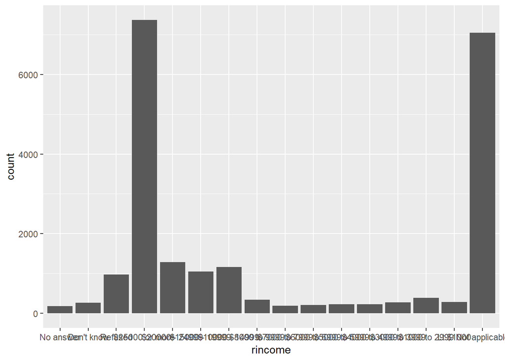

```r
#default
ggplot(gss_cat, aes(x = rincome)) + geom_bar()
```

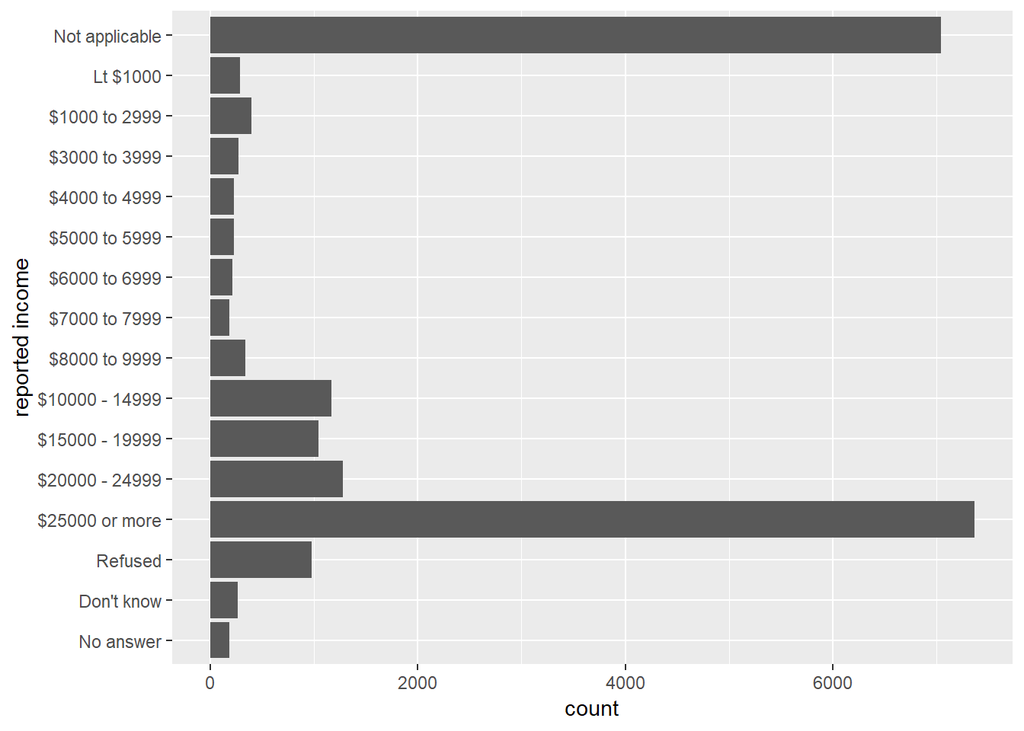

```r
#two improvements
ggplot(gss_cat, aes(x = rincome)) + geom_bar() + labs(x = "reported income") + coord_flip()
```

2. The numbers that are higher than 20 might be unreasonably high because it leaves little time for daily necessary activities in life in such situation. My preferred option is to set these unusual values as NA because they seem to be intentionally or unintentionally errorneous answers.

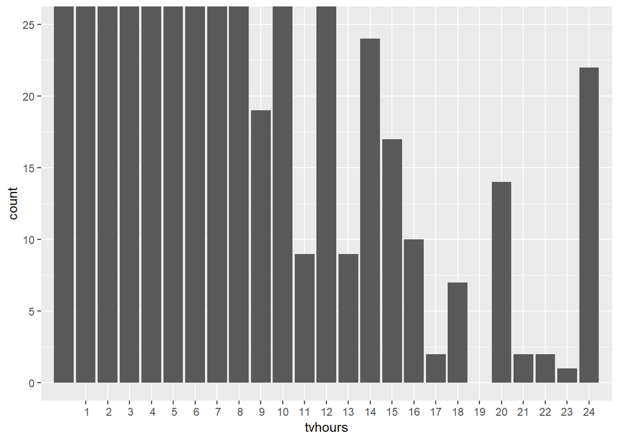

```r
ggplot(gss_cat, aes(x = tvhours)) +
  geom_bar() +
  scale_x_discrete( limits = 1:24 ) +
  coord_cartesian(ylim = c(0, 25))
```

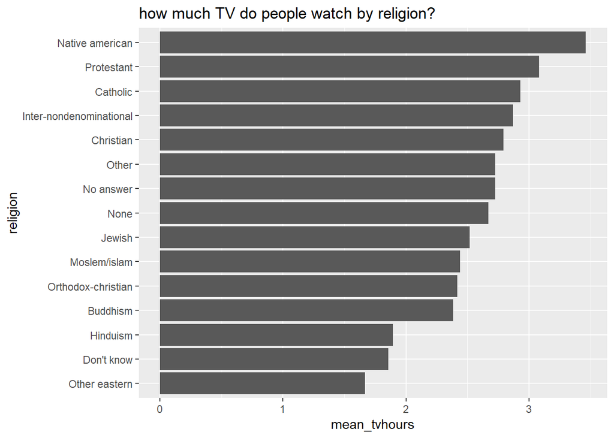

```r
gss_clean <-
  gss_cat %>%
  mutate(tvhours = ifelse(tvhours > 20, NA, tvhours))

gss_clean %>%
  group_by(relig) %>%
  summarise(mean_tvhours = mean(tvhours, na.rm = TRUE)) %>%
  ggplot(aes(x = reorder(relig, mean_tvhours), y = mean_tvhours)) +
  geom_col() +
  labs(x = "religion", title = "how much TV do people watch by religion?") +
  coord_flip()
```

3. Because in the plot, the categories of rincome are placed from bottom to top, moving “Not applicable” to in front of the levels makes “Not applicable” move to the bottom in the plot.

```r
levels(gss_cat$rincome)
```

```
##  [1] "No answer"      "Don't know"     "Refused"        "$25000 or more"
##  [5] "$20000 - 24999" "$15000 - 19999" "$10000 - 14999" "$8000 to 9999"
##  [9] "$7000 to 7999"  "$6000 to 6999"  "$5000 to 5999"  "$4000 to 4999"
## [13] "$3000 to 3999"  "$1000 to 2999"  "Lt $1000"       "Not applicable"
```

4. In general, the proportion of people identifying as Democrat is relatively stable, the proportion of people identifying as Republican is declining after 2004 and the proportion of people identifying as Independent is increasing after 2004.

```r
par_sum <-
  gss_cat %>%
  group_by(year) %>%
  summarise(prop_Demo = sum(str_detect(partyid, "democrat"))/n(),
            prop_Rep  = sum(str_detect(partyid, "republican"))/n(),
            prop_Ind  = sum(str_detect(partyid, "Ind"))/n()
            )
par_sum <- gather(par_sum, key = "party", value = "proportion", -year)

print(par_sum)
```

```
## # A tibble: 24 x 3
##     year party     proportion
##    <int> <chr>          <dbl>
##  1  2000 prop_Demo      0.327
##  2  2002 prop_Demo      0.334
##  3  2004 prop_Demo      0.341
##  4  2006 prop_Demo      0.318
##  5  2008 prop_Demo      0.356
##  6  2010 prop_Demo      0.341
##  7  2012 prop_Demo      0.354
##  8  2014 prop_Demo      0.325
##  9  2000 prop_Rep       0.243
## 10  2002 prop_Rep       0.276
## # ... with 14 more rows
```

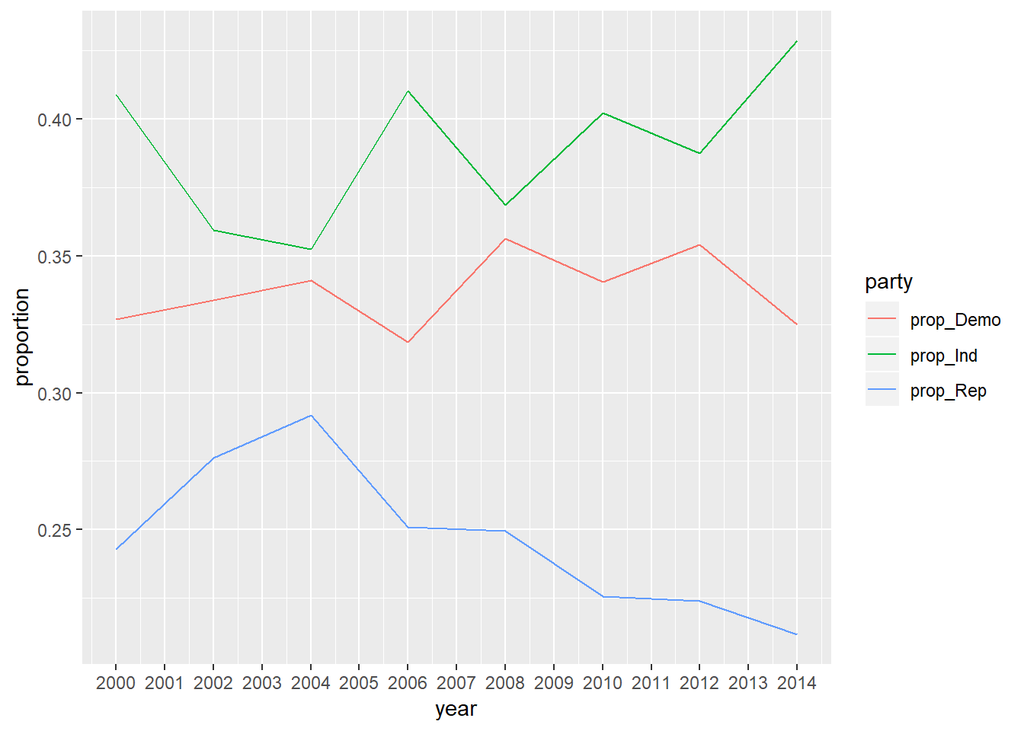

```r
ggplot(par_sum,aes(x = year, y = proportion, color = party)) + geom_line() + scale_x_continuous(breaks = c(2000:2014))
```

```r
gss_cat_recode <-
  mutate(gss_cat, partyid = fct_recode(partyid,
    "Strong Republican"    = "Strong republican",
    "Mild Republican"      = "Not str republican",
    "Rep-ish Independent"  = "Ind,near rep",
    "Dem-ish Independent"  = "Ind,near dem",
    "Mild Democrat"        = "Not str democrat",
    "Strong Democrat"      = "Strong democrat",
    "Other"                = "No answer",
    "Other"                = "Don't know",
    "Other"                = "Other party"
  ))
unique(gss_cat_recode$partyid)
```

```
## [1] Rep-ish Independent Mild Republican     Independent
## [4] Mild Democrat       Strong Democrat     Dem-ish Independent
## [7] Strong Republican   Other
## 8 Levels: Other Strong Republican Mild Republican ... Strong Democrat
```

# 3 understanding the structure of the data

1. This does not hold for all violations. The following violation types do not double: [1] “DISABLED PARKING ZONE”  
   [2] “PARK OR BLOCK ALLEY”  
   [3] “DISABLED PARKING”  
   [4] “BLOCK ACCESS/ALLEY/DRIVEWAY/FIRELANE”  
   [5] “PARK IN FIRE LANE”  
   [6] “SMOKED/TINTED WINDOWS PARKED/STANDING”  
   [7] “OBSTRUCTED OR IMPROPERLY TINTED WINDOWS” [8] “PARK/STAND ON BICYCLE PATH”  
   [9] “INVALID PLACARD”  
   [10] “NO CITY STICKER VEHICLE OVER 16,000 LBS.”

For these violation types, if the original fine is not higher than 250 dollars, it is increased to 250. If the violation type is “NO CITY STICKER VEHICLE OVER 16,000 LBS” and is fined 500 dollars, then it will increase to 775 dollars.

```r
tickets_1pct <-
  read_csv("D:\\R\\dataset\\parking_tickets_one_percent.csv",
           col_types = cols(ticket_number = col_double())
           )
not_dble<- tickets_1pct %>%
  filter(fine_level2_amount != fine_level1_amount*2) %>%
  select(violation_description, fine_level1_amount, fine_level2_amount, everything())
not_dble
```

```
## # A tibble: 4,004 x 24
##    violation_descr~ fine_level1_amo~ fine_level2_amo~    X1 ticket_number
##    <chr>                       <int>            <int> <int>         <dbl>
##  1 DISABLED PARKIN~              200              250    14      52432501
##  2 DISABLED PARKIN~              200              250    27      51638401
##  3 PARK OR BLOCK A~              150              250    41      51507201
##  4 PARK OR BLOCK A~              150              250    47      51540701
##  5 PARK OR BLOCK A~              150              250    68      51401001
##  6 PARK OR BLOCK A~              150              250   152      51368301
##  7 DISABLED PARKIN~              200              250   172      51352501
##  8 DISABLED PARKIN~              200              250   182    9065922201
##  9 DISABLED PARKIN~              200              250   201      51492101
## 10 DISABLED PARKIN~              200              250   331      51262001
## # ... with 3,994 more rows, and 19 more variables: issue_date <dttm>,
## #   violation_location <chr>, license_plate_number <chr>,
## #   license_plate_state <chr>, license_plate_type <chr>, zipcode <chr>,
## #   violation_code <chr>, unit <int>, unit_description <chr>,
## #   vehicle_make <chr>, current_amount_due <dbl>, total_payments <dbl>,
## #   ticket_queue <chr>, ticket_queue_date <date>, notice_level <chr>,
## #   hearing_disposition <chr>, notice_number <dbl>, officer <chr>,
## #   address <chr>
```

```r
unique(not_dble$violation_description)
```

```
##  [1] "DISABLED PARKING ZONE"
##  [2] "PARK OR BLOCK ALLEY"
##  [3] "DISABLED PARKING"
##  [4] "BLOCK ACCESS/ALLEY/DRIVEWAY/FIRELANE"
##  [5] "PARK IN FIRE LANE"
##  [6] "SMOKED/TINTED WINDOWS PARKED/STANDING"
##  [7] "OBSTRUCTED OR IMPROPERLY TINTED WINDOWS"
##  [8] "PARK/STAND ON BICYCLE PATH"
##  [9] "INVALID PLACARD"
## [10] "NO CITY STICKER VEHICLE OVER 16,000 LBS."
```

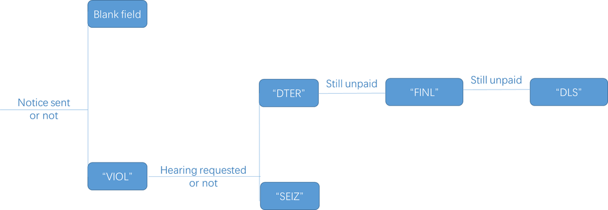

```r
#notice level
knitr::include_graphics("D:\\R\\ps7-fall-2018-caiy0233\\notice level.png", dpi = NA)
```

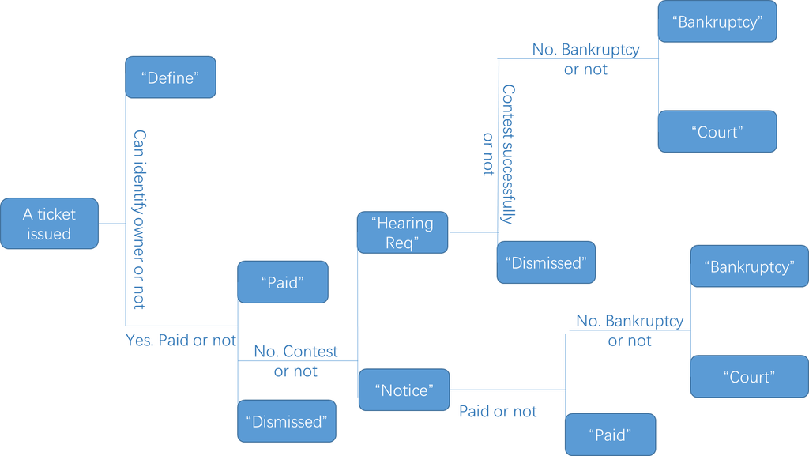

```r
#ticket queue
knitr::include_graphics("D:\\R\\ps7-fall-2018-caiy0233\\ticket queue.png", dpi = NA)
```

```r
tickets_1pct %>%
  group_by(violation_description) %>%
  summarise(n_code = n_distinct(violation_code))
```

```
## # A tibble: 119 x 2
##    violation_description                   n_code
##    <chr>                                    <int>
##  1 2 REAR TRAILER LAMPS REQ'D VISIBLE 500'      1
##  2 20'OF CROSSWALK                              1
##  3 3-7 AM SNOW ROUTE                            2
##  4 ABANDONED VEH. FOR 7 DAYS OR INOPERABLE      1
##  5 BACK-UP LAMP LIT DURING OPERATION            1
##  6 BLOCK ACCESS/ALLEY/DRIVEWAY/FIRELANE         1
##  7 BLOCK ALLEY                                  1
##  8 BRAKES REQUIRED DURING OPERATION             1
##  9 BRAKES REQUIRED IN GOOD WORKING ORDER        1
## 10 BURGLAR ALARM SOUNDING OVER 4 MINUTES        1
## # ... with 109 more rows
```

```r
tickets_1pct %>%
  group_by(violation_description, violation_code) %>%
  summarise(n_tickets = n())
```

```
## # A tibble: 124 x 3
## # Groups:   violation_description [?]
##    violation_description                   violation_code n_tickets
##    <chr>                                   <chr>              <int>
##  1 2 REAR TRAILER LAMPS REQ'D VISIBLE 500' 0976050E               4
##  2 20'OF CROSSWALK                         0964100F             393
##  3 3-7 AM SNOW ROUTE                       0964060              827
##  4 3-7 AM SNOW ROUTE                       0964060B              12
##  5 ABANDONED VEH. FOR 7 DAYS OR INOPERABLE 0980110A            1104
##  6 BACK-UP LAMP LIT DURING OPERATION       0976070C               2
##  7 BLOCK ACCESS/ALLEY/DRIVEWAY/FIRELANE    0964100C            1579
##  8 BLOCK ALLEY                             0964130B              20
##  9 BRAKES REQUIRED DURING OPERATION        0976010A               1
## 10 BRAKES REQUIRED IN GOOD WORKING ORDER   0976020E               1
## # ... with 114 more rows
```

```r
tickets_1pct %>%
  group_by(violation_code) %>%
  summarise(n_code = n_distinct(violation_description))
```

```
## # A tibble: 116 x 2
##    violation_code n_code
##    <chr>           <int>
##  1 0912060             1
##  2 0940060             1
##  3 0940080             1
##  4 0940170             1
##  5 0940220             1
##  6 0964020A            1
##  7 0964020B            1
##  8 0964020C            1
##  9 0964030B            1
## 10 0964040B            2
## # ... with 106 more rows
```

```r
tickets_1pct %>%
  group_by(violation_code, violation_description) %>%
  summarise(n_tickets = n())
```

```
## # A tibble: 124 x 3
## # Groups:   violation_code [?]
##    violation_code violation_description                           n_tickets
##    <chr>          <chr>                                               <int>
##  1 0912060        STAND, PARK, OR OTHER USE OF BUS LANE                1233
##  2 0940060        PARK/STAND ON BICYCLE PATH                            236
##  3 0940080        PARKED/STANDING UNATTENDED W/MOTOR RUNNI               81
##  4 0940170        UNSAFE CONDITION                                       64
##  5 0940220        NO OPERATOR SIGNAL                                     32
##  6 0964020A       WRONG DIRECTION OR 12'' FROM CURB                    1111
##  7 0964020B       OBSTRUCT ROADWAY                                     1577
##  8 0964020C       PARK MOTORCYCLE/SCOOTER PARK AT 90 DEGREE ANGLE        14
##  9 0964030B       OUTSIDE DIAGONAL MARKINGS                             110
## 10 0964040B       STREET CLEANING                                     28712
## # ... with 114 more rows
```

5. Yes. Items like “EXPIRED PLATES OR TEMPORARY REGISTRATION” and “EXPIRED PLATE OR TEMPORARY REGISTRATION” seem redundant. “EXPIRED PLATES OR TEMPORARY REGISTRATION” corresponds to violation code 0976160F and “EXPIRED PLATE OR TEMPORARY REGISTRATION” corresponds to 0976160B

```r
top_50 <-
  tickets_1pct %>%
  group_by(violation_description) %>%
  summarise(n = n(), violation_code = first(violation_code)) %>%
  arrange(desc(n)) %>%
  slice(1:50)

print(top_50)
```

```
## # A tibble: 50 x 3
##    violation_description                                  n violation_code
##    <chr>                                              <int> <chr>
##  1 EXPIRED PLATES OR TEMPORARY REGISTRATION           44811 0976160F
##  2 STREET CLEANING                                    28712 0964040B
##  3 RESIDENTIAL PERMIT PARKING                         23683 0964090E
##  4 EXP. METER NON-CENTRAL BUSINESS DISTRICT           20600 0964190A
##  5 PARKING/STANDING PROHIBITED ANYTIME                19753 0964150B
##  6 EXPIRED METER OR OVERSTAY                          18756 0964190
##  7 REAR AND FRONT PLATE REQUIRED                      15829 0976160A
##  8 NO CITY STICKER VEHICLE UNDER/EQUAL TO 16,000 LBS. 14246 0964125B
##  9 RUSH HOUR PARKING                                  11965 0964080A
## 10 NO CITY STICKER OR IMPROPER DISPLAY                10773 0964125
## # ... with 40 more rows
```

# 4 revenue increase from “missing city sticker” tickets

1. The old violation code for missing city sticker is 0964125 and 0976170. The new violation code for missing city sticker is 0964125B (under/ equal to 16000LBS) . Under the old codes, the cost of an initial oﬀense was 120 dollars and it is 200 dollars under the new one.

```r
# old and new violation code
desc_code <-
  tickets_1pct %>%
  group_by(violation_description, violation_code) %>%
  summarise(issue_date = first(issue_date)) %>%
  filter(str_detect(violation_description, "NO CITY STICKER")) %>%
  arrange(issue_date)
print(desc_code)
```

```
## # A tibble: 4 x 3
## # Groups:   violation_description [3]
##   violation_description                 violation_code issue_date
##   <chr>                                 <chr>          <dttm>
## 1 NO CITY STICKER OR IMPROPER DISPLAY   0964125        2007-01-01 10:51:00
## 2 NO CITY STICKER OR IMPROPER DISPLAY   0976170        2007-02-06 17:29:00
## 3 NO CITY STICKER VEHICLE UNDER/EQUAL ~ 0964125B       2012-02-25 02:00:00
## 4 NO CITY STICKER VEHICLE OVER 16,000 ~ 0964125C       2012-02-26 08:36:00
```

```r
# cost of an initial offense

tickets_1pct %>%
  group_by(violation_code) %>%
  summarise(fine_level1_amount = first(fine_level1_amount), issue_date = first(issue_date)) %>%
  filter(str_detect(violation_code, "0964125|0976170"))
```

```
## # A tibble: 5 x 3
##   violation_code fine_level1_amount issue_date
##   <chr>                       <int> <dttm>
## 1 0964125                       120 2007-01-01 10:51:00
## 2 0964125B                      200 2012-02-25 02:00:00
## 3 0964125C                      500 2012-02-26 08:36:00
## 4 0964125D                       30 2012-02-28 08:24:00
## 5 0976170                       120 2007-02-06 17:29:00
```

2. The number of missing sticker tickets decreased slowly over time before 2011 and then rised in 2012 and 2013, followed by an obvious decrease in 2014. From 2015 to 2017, it remains relatively stable.

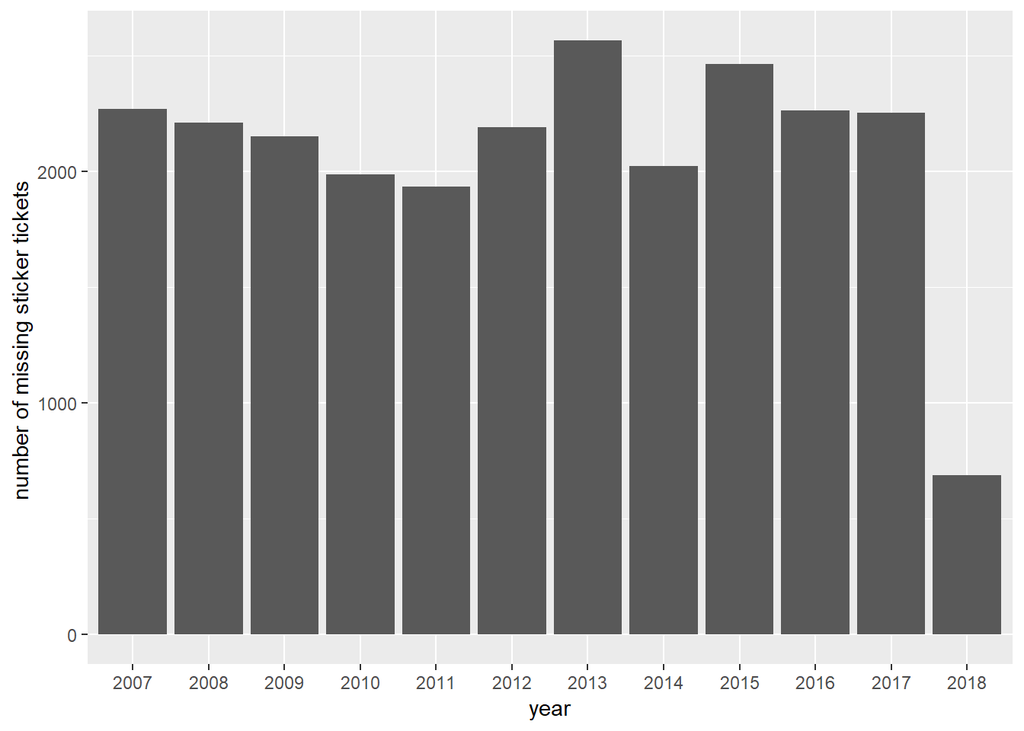

```r
no_sticker <-
  tickets_1pct %>%
  mutate(violation_code = fct_collapse(violation_code, "0964125" = c("0964125", "0976170", "0964125B"))) %>%
  filter(violation_code == "0964125")

no_sticker <- mutate(no_sticker, year = str_sub(issue_date, 1, 4))

no_sticker %>%
  group_by(year) %>%
  summarise(n = n()) %>%
  ggplot(aes(x = year, y = n)) + geom_col() + labs(y = "number of missing sticker tickets ")
```

3. The price increase occurred in 2012.

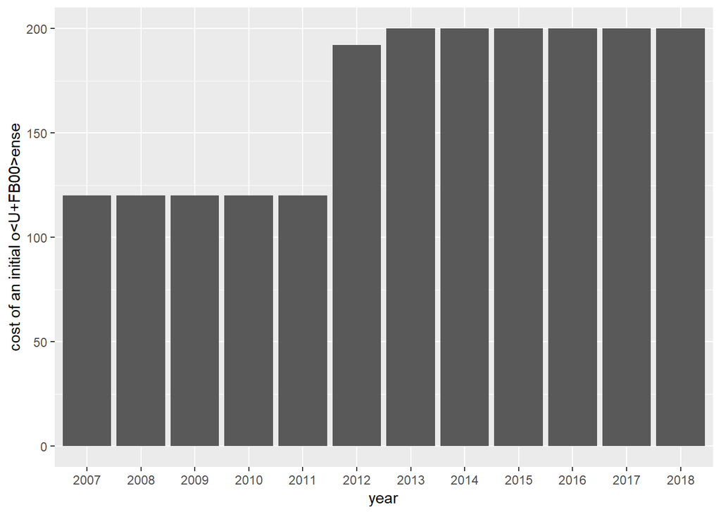

```r
no_sticker %>%
  group_by(year) %>%
  summarise(mean_ini_price = mean(fine_level1_amount)) %>%
  ggplot(aes(x = year, y = mean_ini_price)) + geom_col() + labs(y = "cost of an initial oﬀense")
```

```r
no_sticker %>%
  group_by(year) %>%
  summarise(min_ini_price  = min(fine_level1_amount),
            mean_ini_price = mean(fine_level1_amount),
            max_ini_price  = max(fine_level1_amount)
            )
```

```
## # A tibble: 12 x 4
##    year  min_ini_price mean_ini_price max_ini_price
##    <chr>         <dbl>          <dbl>         <dbl>
##  1 2007            120           120            120
##  2 2008            120           120            120
##  3 2009            120           120            120
##  4 2010            120           120            120
##  5 2011            120           120            120
##  6 2012            120           192.           200
##  7 2013            200           200            200
##  8 2014            200           200            200
##  9 2015            200           200            200
## 10 2016            200           200            200
## 11 2017            200           200            200
## 12 2018            200           200            200
```

4. The calendar year prior to the increase is 2011 and there were 1935 missing sticker tickets that were issued. By increasing the intial price from 120 to 200, she should have projected a revenue of 1935*(200-120)*100 = 15480000(it is multiplied by 100 because we are using the one percent sample of the whole dataset) .

```r
no_sticker %>%
  group_by(year) %>%
  summarise(n = n())
```

```
## # A tibble: 12 x 2
##    year      n
##    <chr> <int>
##  1 2007   2271
##  2 2008   2213
##  3 2009   2152
##  4 2010   1987
##  5 2011   1935
##  6 2012   2192
##  7 2013   2567
##  8 2014   2025
##  9 2015   2467
## 10 2016   2264
## 11 2017   2256
## 12 2018    690
```

```r
1935*(200-120)*100
```

```
## [1] 15480000
```

5. The repayment rates on this type of ticket decreased in the calendar year after the increase went into eﬀect. If the City had not started issuing more of these tickets, its change in revenue woulf have been 1935*100*(200*0.482 - 120*0.540) = 6114600.

```r
(rate_repay <-
  no_sticker %>%
  group_by(year) %>%
  summarise(rate_repay = sum(ticket_queue == "Paid", na.rm = TRUE)/n()))
```

```
## # A tibble: 12 x 2
##    year  rate_repay
##    <chr>      <dbl>
##  1 2007       0.551
##  2 2008       0.579
##  3 2009       0.531
##  4 2010       0.520
##  5 2011       0.540
##  6 2012       0.482
##  7 2013       0.406
##  8 2014       0.384
##  9 2015       0.406
## 10 2016       0.408
## 11 2017       0.370
## 12 2018       0.201
```

```r
1935*100*(200*0.482 - 120*0.540)
```

```
## [1] 6114600
```

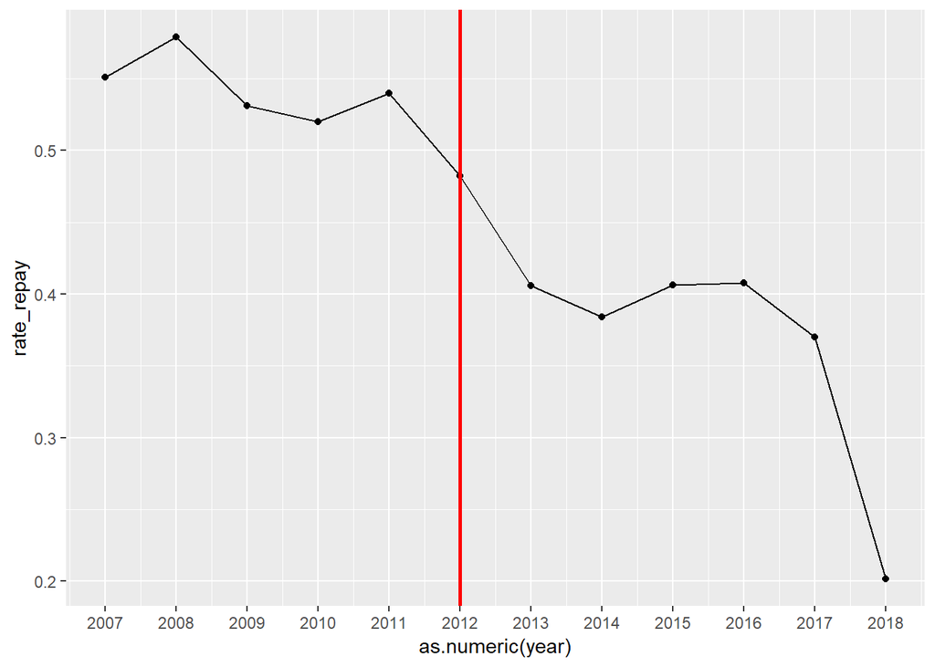

```r
ggplot(rate_repay, aes(x = as.numeric(year),
                       y = rate_repay,
                       group = 1)) +
  geom_line() +
  geom_point() +
  scale_x_continuous(breaks = 2007:2018)+
  geom_vline(xintercept = 2012,
             color = "red",
             size=1,
             show.legend = TRUE)
```

7. Three ticket types she should have increased: EXPIRED METER OR OVERSTAY, EXPIRED PLATES OR TEMPORARY REGISTRATION and STREET CLEANING.  
   Reason: In order to maximize the revenue increase, we need to take into consideration both whether the number of issued tickets under a certain violation type is large enough and whether the repayment rate is high enough. Therefore we can construct a viable “margin” = tickets number * repayment rate, which represents how much revenue is increased if we increase the fine for the violation type by 1 dollar(Assuming there is no behavioral response). We choose EXPIRED METER OR OVERSTAY, EXPIRED PLATES OR TEMPORARY REGISTRATION and STREET CLEANING because they can provide highest margin.

```r
for_revenue <-
  tickets_1pct %>%
  mutate(year = str_sub(issue_date, 1, 4)) %>%
  filter(as.numeric(year) < 2012) %>%
  group_by(violation_description) %>%
  summarise(n = n(), rate_repay = sum(ticket_queue == "Paid", na.rm = TRUE)/n(), margin = n*rate_repay) %>%
  arrange(desc(margin))

print(for_revenue)
```

```
## # A tibble: 99 x 4
##    violation_description                        n rate_repay margin
##    <chr>                                    <int>      <dbl>  <dbl>
##  1 EXPIRED METER OR OVERSTAY                18117      0.805  14580
##  2 EXPIRED PLATES OR TEMPORARY REGISTRATION 21906      0.608  13316
##  3 STREET CLEANING                          11370      0.825   9383
##  4 RESIDENTIAL PERMIT PARKING               11452      0.761   8718
##  5 PARKING/STANDING PROHIBITED ANYTIME       9673      0.727   7032
##  6 NO CITY STICKER OR IMPROPER DISPLAY      10558      0.545   5752
##  7 RUSH HOUR PARKING                         7121      0.783   5576
##  8 REAR AND FRONT PLATE REQUIRED             8339      0.608   5066
##  9 EXP. METER NON-CENTRAL BUSINESS DISTRICT  3503      0.842   2951
## 10 STREET CLEANING OR SPECIAL EVENT          3370      0.788   2654
## # ... with 89 more rows
```

8. 1. If she try to raise ticket prices for violations that would aﬀect households in high income zip codes more than low income zip codes, she can choose to raise the price for EXPIRED PLATES OR TEMPORARY REGISTRATION, STREET CLEANING and RESIDENTIAL PERMIT PARKING.
2. If she raises the ticket price by $80 for each of these tickets, the additional revenue can she expect for each violation type is :

EXPIRED PLATES OR TEMPORARY REGISTRATION: 4345 * 100 * 0.636 * 80 = 22107360  
STREET CLEANING: 2810 * 100 * 0.829 * 80 = 18635920  
RESIDENTIAL PERMIT PARKING: 1908 * 100 * 0.774 * 80 = 11814336

```r
#merge

tickets_1pct <-
  tickets_1pct %>%
  mutate(zipcode = str_trim(substr(zipcode, 1, 5)))

census_data_zip <- read_csv(file = "D:\\R\\dataset\\ACS_16_5YR_S1903_with_ann.csv", na = "-")
census_data_zip <-
  census_data_zip %>%
  select("GEO.display-label", HC01_EST_VC02, HC02_EST_VC02,HC01_EST_VC05) %>%
  mutate(
         zipcode = as.character(str_trim(str_replace(`GEO.display-label`,"ZCTA5",""))),
         share_black = as.numeric(HC01_EST_VC05)/100,
         median_income = as.numeric(HC01_EST_VC02)
         ) %>%
  select(zipcode, share_black, median_income)
zip_joined <-
  left_join(tickets_1pct, census_data_zip, by = "zipcode")

higher_income <- zip_joined %>% filter(median_income > 25000)
higher_income %>%
  group_by(violation_description) %>%
  summarise(n = n()) %>%
  arrange(desc(n)) %>%
  slice(1:3)
```

```
## # A tibble: 3 x 2
##   violation_description                        n
##   <chr>                                    <int>
## 1 EXPIRED PLATES OR TEMPORARY REGISTRATION  9753
## 2 STREET CLEANING                           7472
## 3 RESIDENTIAL PERMIT PARKING                4916
```

```r
#EXPIRED PLATES OR TEMPORARY REGISTRATION
tickets_1pct <-
  tickets_1pct %>%
  mutate(violation_code = fct_collapse(violation_description, "EXPIRED PLATES OR TEMPORARY REGISTRATION" = c("EXPIRED PLATES OR TEMPORARY REGISTRATION", "EXPIRED PLATE OR TEMPORARY REGISTRATION")), year = str_sub(issue_date, 1, 4))

expire_plates <-
  tickets_1pct %>%
  filter(violation_description == "EXPIRED PLATES OR TEMPORARY REGISTRATION") %>%
  group_by(year) %>%
  summarise(n = n(), rate_repay = sum(ticket_queue == "Paid", na.rm = TRUE)/n())

print(expire_plates)
```

```
## # A tibble: 11 x 3
##    year      n rate_repay
##    <chr> <int>      <dbl>
##  1 2007   4160      0.586
##  2 2008   4543      0.611
##  3 2009   4604      0.601
##  4 2010   4254      0.604
##  5 2011   4345      0.636
##  6 2012   3797      0.620
##  7 2013   4036      0.604
##  8 2014   4363      0.612
##  9 2015   4223      0.591
## 10 2016   4459      0.619
## 11 2017   2027      0.516
```

```r
4345*100*0.636*80
```

```
## [1] 22107360
```

```r
#STREET CLEANING
street_cl <-
  tickets_1pct %>%
  filter(violation_description == "STREET CLEANING") %>%
  group_by(year) %>%
  summarise(n = n(), rate_repay = sum(ticket_queue == "Paid", na.rm = TRUE)/n())

print(street_cl)
```

```
## # A tibble: 12 x 3
##    year      n rate_repay
##    <chr> <int>      <dbl>
##  1 2007     13      0.846
##  2 2008   3255      0.814
##  3 2009   2628      0.826
##  4 2010   2664      0.834
##  5 2011   2810      0.829
##  6 2012   2839      0.835
##  7 2013   3004      0.810
##  8 2014   2904      0.829
##  9 2015   2939      0.825
## 10 2016   2673      0.811
## 11 2017   2539      0.772
## 12 2018    444      0.349
```

```r
2810 * 100 * 0.829 * 80
```

```
## [1] 18635920
```

```r
#RESIDENTIAL PERMIT PARKING
permit_parking <-
  tickets_1pct %>%
  filter(violation_description == "RESIDENTIAL PERMIT PARKING") %>%
  group_by(year) %>%
  summarise(n = n(), rate_repay = sum(ticket_queue == "Paid", na.rm = TRUE)/n())

print(permit_parking)
```

```
## # A tibble: 12 x 3
##    year      n rate_repay
##    <chr> <int>      <dbl>
##  1 2007   2718      0.771
##  2 2008   2441      0.755
##  3 2009   2335      0.751
##  4 2010   2050      0.755
##  5 2011   1908      0.774
##  6 2012   1987      0.758
##  7 2013   1888      0.756
##  8 2014   1777      0.739
##  9 2015   1910      0.751
## 10 2016   1888      0.743
## 11 2017   2099      0.696
## 12 2018    682      0.468
```

```r
1908 * 100 * 0.774 * 80
```

```
## [1] 11814336
```